# lab-06

Author

Andre Gala-Garza

Published

February 19, 2026

**Disclaimer:** Generative AI was used to assist with templating and writing code in this assignment; however, this code was checked manually and edited by hand to ensure accuracy.

**Source:** OpenAI. (2026). *ChatGPT (GPT-5.2 Thinking)* [Large language model]. https://chatgpt.com/.

# 0. Load packages and data

```r
library("dplyr")
library("ggplot2")
library("tidytext")
library("tidyr")
library("forcats")
library("stringr")
```

```r
url <- 'https://raw.githubusercontent.com/dmcable/BIOSTAT620W26/main/data/mtsamples/mtsamples.csv'
if (!file.exists("mtsamples.csv"))
  download.file(
    url = url,
    destfile = "mtsamples.csv",
    method   = "libcurl",
    timeout  = 60
    )
mtsamples <- read.csv('mtsamples.csv')
```

```r
dim(mtsamples)
```

```
[1] 4999    6
```

```r
head(mtsamples)
```

```
  X
1 0
2 1
3 2
4 3
5 4
6 5
                                                                                                                                                                                                                            description
1                                                                                                                                                                      A 23-year-old white female presents with complaint of allergies.
2                                                                                                                                                                                              Consult for laparoscopic gastric bypass.
3                                                                                                                                                                                              Consult for laparoscopic gastric bypass.
4                                                                                                                                                                                                                2-D M-Mode. Doppler.
5                                                                                                                                                                                                                    2-D Echocardiogram
6  Morbid obesity.  Laparoscopic antecolic antegastric Roux-en-Y gastric bypass with EEA anastomosis.  This is a 30-year-old female, who has been overweight for many years.  She has tried many different diets, but is unsuccessful.
            medical_specialty                               sample_name
```

[output cut: 20 more lines]

```r
colnames(mtsamples)
```

```
[1] "X"                 "description"       "medical_specialty"
[4] "sample_name"       "transcription"     "keywords"
```

```r
str(mtsamples)
```

```
'data.frame':   4999 obs. of  6 variables:
 $ X                : int  0 1 2 3 4 5 6 7 8 9 ...
 $ description      : chr  " A 23-year-old white female presents with complaint of allergies." " Consult for laparoscopic gastric bypass." " Consult for laparoscopic gastric bypass." " 2-D M-Mode. Doppler.  " ...
 $ medical_specialty: chr  " Allergy / Immunology" " Bariatrics" " Bariatrics" " Cardiovascular / Pulmonary" ...
 $ sample_name      : chr  " Allergic Rhinitis " " Laparoscopic Gastric Bypass Consult - 2 " " Laparoscopic Gastric Bypass Consult - 1 " " 2-D Echocardiogram - 1 " ...
 $ transcription    : chr  "SUBJECTIVE:,  This 23-year-old white female presents with complaint of allergies.  She used to have allergies w"| __truncated__ "PAST MEDICAL HISTORY:, He has difficulty climbing stairs, difficulty with airline seats, tying shoes, used to p"| __truncated__ "HISTORY OF PRE…
 $ keywords         : chr  "allergy / immunology, allergic rhinitis, allergies, asthma, nasal sprays, rhinitis, nasal, erythematous, allegr"| __truncated__ "bariatrics, laparoscopic gastric bypass, weight loss programs, gastric bypass, atkin's diet, weight watcher's, "| __truncated__ "bariatrics, la…
```

# 1. Identify specialties

```r
specialties <- mtsamples %>%
  count(medical_specialty) %>%
  arrange(desc(n))
specialties
```

```
                medical_specialty    n
1                         Surgery 1103
2      Consult - History and Phy.  516
3      Cardiovascular / Pulmonary  372
4                      Orthopedic  355
5                       Radiology  273
6                General Medicine  259
7                Gastroenterology  230
8                       Neurology  223
9   SOAP / Chart / Progress Notes  166
10        Obstetrics / Gynecology  160
11                        Urology  158
12              Discharge Summary  108
13           ENT - Otolaryngology   98
14                   Neurosurgery   94
```

[output cut: 26 more lines]

From examining the table of medical specialties and their counts, we find that there are 40 specialties in total. The most common specialty by far is “Surgery”, with over 1,100 records. However, there are also more specific specialties that overlap with surgery, such as “Neurosurgery” with 94 records, and “Cosmetic / Plastic Surgery” with only 27 records.

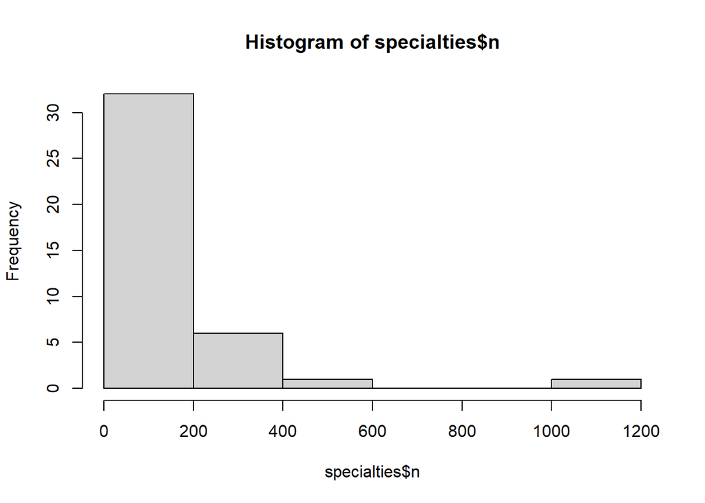

```r
hist(specialties$n)
```

From the distribution of the specialty frequencies, we find that they are not evenly distributed; instead, the distribution is heavily right-skewed, with some categories having far more records than others.

# 2. Tokenize and visualize

```r
mtsamples_tokens <- mtsamples %>%
  unnest_tokens(token, transcription)
head(mtsamples_tokens)
```

```
  X                                                       description
1 0  A 23-year-old white female presents with complaint of allergies.
2 0  A 23-year-old white female presents with complaint of allergies.
3 0  A 23-year-old white female presents with complaint of allergies.
4 0  A 23-year-old white female presents with complaint of allergies.
5 0  A 23-year-old white female presents with complaint of allergies.
6 0  A 23-year-old white female presents with complaint of allergies.
      medical_specialty         sample_name
1  Allergy / Immunology  Allergic Rhinitis
2  Allergy / Immunology  Allergic Rhinitis
3  Allergy / Immunology  Allergic Rhinitis
4  Allergy / Immunology  Allergic Rhinitis
5  Allergy / Immunology  Allergic Rhinitis
6  Allergy / Immunology  Allergic Rhinitis
                                                                                                                             keywords
1 allergy / immunology, allergic rhinitis, allergies, asthma, nasal sprays, rhinitis, nasal, erythematous, allegra, sprays, allergic,
2 allergy / immunology, allergic rhinitis, allergies, asthma, nasal sprays, rhinitis, nasal, erythematous, allegra, sprays, allergic,
3 allergy / immunology, allergic rhinitis, allergies, asthma, nasal sprays, rhinitis, nasal, erythematous, allegra, sprays, allergic,
4 allergy / immunology, allergic rhinitis, allergies, asthma, nasal sprays, rhinitis, nasal, erythematous, allegra, sprays, allergic,
5 allergy / immunology, allergic rhinitis, allergies, asthma, nasal sprays, rhinitis, nasal, erythematous, allegra, sprays, allergic,
6 allergy / immunology, allergic rhinitis, allergies, asthma, nasal sprays, rhinitis, nasal, erythematous, allegra, sprays, allergic,
       token
1 subjective
2       this
3         23
4       year
5        old
6      white
```

```r
head(mtsamples_tokens$token)
```

```
[1] "subjective" "this"       "23"         "year"       "old"
[6] "white"
```

```r
mtsamples_token_counts <- mtsamples_tokens %>%
  count(token) %>%
  arrange(desc(n))

head(mtsamples_token_counts)
```

```
  token      n
1   the 149888
2   and  82779
3   was  71765
4    of  59205
5    to  50632
6     a  42812
```

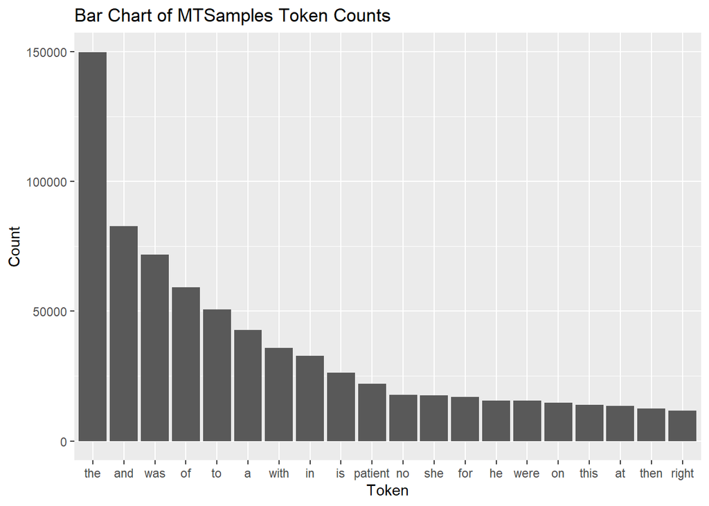

```r
ggplot(data = head(mtsamples_token_counts, n = 20), aes(x = fct_reorder(token, -n), y = n)) +
  geom_bar(stat = "identity") +
  labs(title = "Bar Chart of MTSamples Token Counts",
       y = "Count",
       x = "Token")
```

We see from the bar chart that the most common word in the transcriptions column is “the”, followed by “and”, “was”, “of”, etc. This makes perfect sense because “the” is the most common word in the English language overall, as it is necessary for general communication. Most of these words are stop words that do not provide significant meaning; the exception is “patient”, which is quite common at a count of roughly 20,000, and is expected in a collection of medical descriptions.

# 3. Remove stop words and visualize

```r
mtsamples_tokens <- mtsamples %>%
  unnest_tokens(token, transcription) %>%
  filter(!str_detect(token, "^\\d{1,3}(,\\d{3})*(\\.\\d+)?$")) %>%
  anti_join(stop_words, by = c("token" = "word"))
head(mtsamples_tokens)
```

```
  X                                                       description
1 0  A 23-year-old white female presents with complaint of allergies.
2 0  A 23-year-old white female presents with complaint of allergies.
3 0  A 23-year-old white female presents with complaint of allergies.
4 0  A 23-year-old white female presents with complaint of allergies.
5 0  A 23-year-old white female presents with complaint of allergies.
6 0  A 23-year-old white female presents with complaint of allergies.
      medical_specialty         sample_name
1  Allergy / Immunology  Allergic Rhinitis
2  Allergy / Immunology  Allergic Rhinitis
3  Allergy / Immunology  Allergic Rhinitis
4  Allergy / Immunology  Allergic Rhinitis
5  Allergy / Immunology  Allergic Rhinitis
6  Allergy / Immunology  Allergic Rhinitis
                                                                                                                             keywords
1 allergy / immunology, allergic rhinitis, allergies, asthma, nasal sprays, rhinitis, nasal, erythematous, allegra, sprays, allergic,
2 allergy / immunology, allergic rhinitis, allergies, asthma, nasal sprays, rhinitis, nasal, erythematous, allegra, sprays, allergic,
3 allergy / immunology, allergic rhinitis, allergies, asthma, nasal sprays, rhinitis, nasal, erythematous, allegra, sprays, allergic,
4 allergy / immunology, allergic rhinitis, allergies, asthma, nasal sprays, rhinitis, nasal, erythematous, allegra, sprays, allergic,
5 allergy / immunology, allergic rhinitis, allergies, asthma, nasal sprays, rhinitis, nasal, erythematous, allegra, sprays, allergic,
6 allergy / immunology, allergic rhinitis, allergies, asthma, nasal sprays, rhinitis, nasal, erythematous, allegra, sprays, allergic,
       token
1 subjective
2      white
3     female
4  complaint
5  allergies
6  allergies
```

```r
head(mtsamples_tokens$token)
```

```
[1] "subjective" "white"      "female"     "complaint"  "allergies"
[6] "allergies"
```

```r
mtsamples_token_counts <- mtsamples_tokens %>%
  count(token) %>%
  arrange(desc(n))

head(mtsamples_token_counts)
```

```
      token     n
1   patient 22065
2      left 11258
3   history  9509
4    normal  7526
5 procedure  7463
6      pain  5976
```

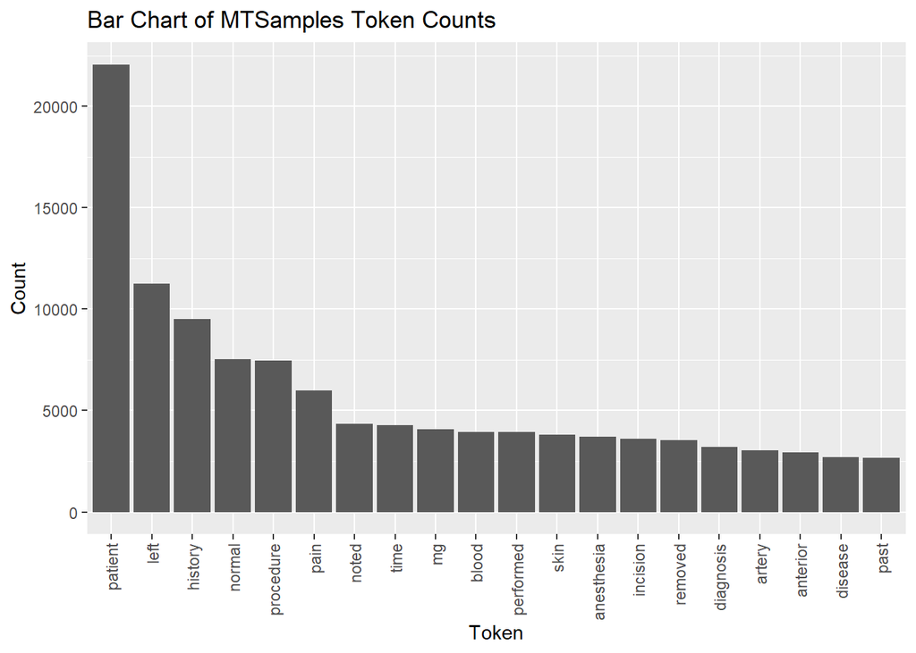

```r
ggplot(data = head(mtsamples_token_counts, n = 20), aes(x = fct_reorder(token, -n), y = n)) +
  geom_bar(stat = "identity") +
  labs(title = "Bar Chart of MTSamples Token Counts",
       y = "Count",
       x = "Token") +
  theme(axis.text.x = element_text(angle = 90, hjust = 1, vjust = 0.5))
```

From this bar graph, we get a much more valuable analysis of the most common tokens: We find that “patient” is the most common word that is not a stopword or a number. Some other common tokens are “history”, “procedure”, “pain”, and “time”, which all refer to common measurements in medical cases. Other common tokens refer to specific biological terms like “blood”, “skin”, and “artery”.

# 4. Tokenize into bigrams and trigrams

Note that this question asks to repeat question 2 (not 3), so we do not remove stopwords or numbers.

We first tokenize into bigrams:

```r
mtsamples_tokens <- mtsamples %>%
  unnest_ngrams(token, transcription, n = 2)
head(mtsamples_tokens)
```

```
  X                                                       description
1 0  A 23-year-old white female presents with complaint of allergies.
2 0  A 23-year-old white female presents with complaint of allergies.
3 0  A 23-year-old white female presents with complaint of allergies.
4 0  A 23-year-old white female presents with complaint of allergies.
5 0  A 23-year-old white female presents with complaint of allergies.
6 0  A 23-year-old white female presents with complaint of allergies.
      medical_specialty         sample_name
1  Allergy / Immunology  Allergic Rhinitis
2  Allergy / Immunology  Allergic Rhinitis
3  Allergy / Immunology  Allergic Rhinitis
4  Allergy / Immunology  Allergic Rhinitis
5  Allergy / Immunology  Allergic Rhinitis
6  Allergy / Immunology  Allergic Rhinitis
                                                                                                                             keywords
1 allergy / immunology, allergic rhinitis, allergies, asthma, nasal sprays, rhinitis, nasal, erythematous, allegra, sprays, allergic,
2 allergy / immunology, allergic rhinitis, allergies, asthma, nasal sprays, rhinitis, nasal, erythematous, allegra, sprays, allergic,
3 allergy / immunology, allergic rhinitis, allergies, asthma, nasal sprays, rhinitis, nasal, erythematous, allegra, sprays, allergic,
4 allergy / immunology, allergic rhinitis, allergies, asthma, nasal sprays, rhinitis, nasal, erythematous, allegra, sprays, allergic,
5 allergy / immunology, allergic rhinitis, allergies, asthma, nasal sprays, rhinitis, nasal, erythematous, allegra, sprays, allergic,
6 allergy / immunology, allergic rhinitis, allergies, asthma, nasal sprays, rhinitis, nasal, erythematous, allegra, sprays, allergic,
            token
1 subjective this
2         this 23
3         23 year
4        year old
5       old white
6    white female
```

```r
head(mtsamples_tokens$token)
```

```
[1] "subjective this" "this 23"         "23 year"         "year old"
[5] "old white"       "white female"
```

```r
mtsamples_token_counts <- mtsamples_tokens %>%
  count(token) %>%
  arrange(desc(n))
```

```r
head(mtsamples_token_counts)
```

```
        token     n
1 the patient 20307
2      of the 19062
3      in the 12790
4      to the 12374
5    was then  6956
6     and the  6350
```

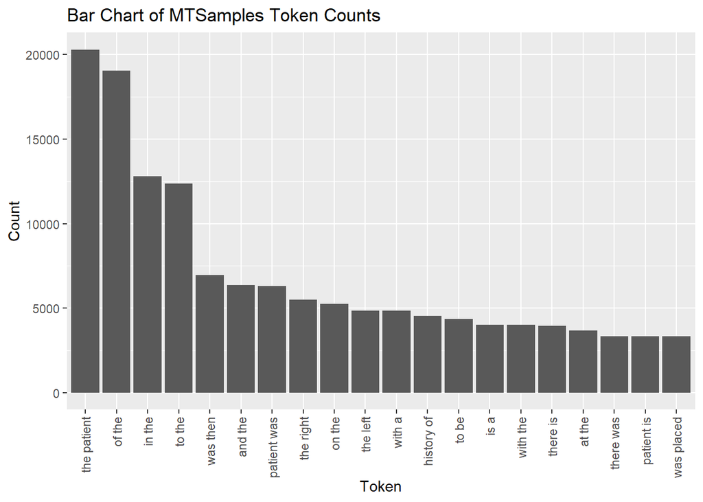

```r
ggplot(data = head(mtsamples_token_counts, n = 20), aes(x = fct_reorder(token, -n), y = n)) +
  geom_bar(stat = "identity") +
  labs(title = "Bar Chart of MTSamples Token Counts",
       y = "Count",
       x = "Token") +
  theme(axis.text.x = element_text(angle = 90, hjust = 1, vjust = 0.5))
```

We see that the most common bigram is “the patient” with over 20,000 appearances, which makes perfect sense given that this is the focus of a medical report. Other bigrams also include the patient, such as “patient was” and “patient is”. However, the rest of the bigrams (besides “history of”) do not provide significant information, much like the stopwords from Question 2.

We now tokenize into trigrams:

```r
mtsamples_tokens <- mtsamples %>%
  unnest_ngrams(token, transcription, n = 3)
head(mtsamples_tokens)
```

```
  X                                                       description
1 0  A 23-year-old white female presents with complaint of allergies.
2 0  A 23-year-old white female presents with complaint of allergies.
3 0  A 23-year-old white female presents with complaint of allergies.
4 0  A 23-year-old white female presents with complaint of allergies.
5 0  A 23-year-old white female presents with complaint of allergies.
6 0  A 23-year-old white female presents with complaint of allergies.
      medical_specialty         sample_name
1  Allergy / Immunology  Allergic Rhinitis
2  Allergy / Immunology  Allergic Rhinitis
3  Allergy / Immunology  Allergic Rhinitis
4  Allergy / Immunology  Allergic Rhinitis
5  Allergy / Immunology  Allergic Rhinitis
6  Allergy / Immunology  Allergic Rhinitis
                                                                                                                             keywords
1 allergy / immunology, allergic rhinitis, allergies, asthma, nasal sprays, rhinitis, nasal, erythematous, allegra, sprays, allergic,
2 allergy / immunology, allergic rhinitis, allergies, asthma, nasal sprays, rhinitis, nasal, erythematous, allegra, sprays, allergic,
3 allergy / immunology, allergic rhinitis, allergies, asthma, nasal sprays, rhinitis, nasal, erythematous, allegra, sprays, allergic,
4 allergy / immunology, allergic rhinitis, allergies, asthma, nasal sprays, rhinitis, nasal, erythematous, allegra, sprays, allergic,
5 allergy / immunology, allergic rhinitis, allergies, asthma, nasal sprays, rhinitis, nasal, erythematous, allegra, sprays, allergic,
6 allergy / immunology, allergic rhinitis, allergies, asthma, nasal sprays, rhinitis, nasal, erythematous, allegra, sprays, allergic,
                  token
1    subjective this 23
2          this 23 year
3           23 year old
4        year old white
5      old white female
6 white female presents
```

```r
head(mtsamples_tokens$token)
```

```
[1] "subjective this 23"    "this 23 year"          "23 year old"
[4] "year old white"        "old white female"      "white female presents"
```

```r
mtsamples_token_counts <- mtsamples_tokens %>%
  count(token) %>%
  arrange(desc(n))
```

```r
head(mtsamples_token_counts)
```

```
               token    n
1    the patient was 6104
2     the patient is 3075
3         as well as 2243
4        there is no 1678
5 the operating room 1532
6       patient is a 1491
```

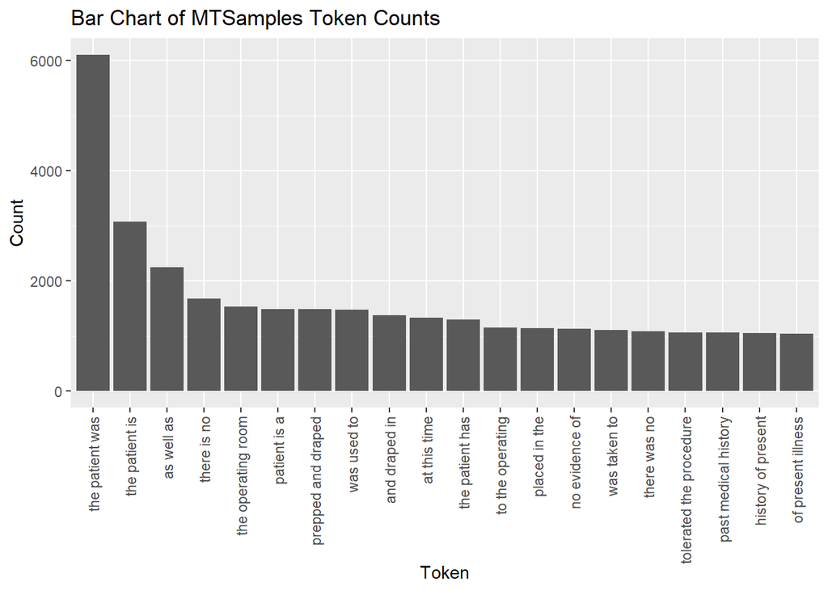

```r
ggplot(data = head(mtsamples_token_counts, n = 20), aes(x = fct_reorder(token, -n), y = n)) +
  geom_bar(stat = "identity") +
  labs(title = "Bar Chart of MTSamples Token Counts",
       y = "Count",
       x = "Token") +
  theme(axis.text.x = element_text(angle = 90, hjust = 1, vjust = 0.5))
```

The most common trigram was “the patient was”, followed by “the patient is”, which once again makes perfect sense in this context. However, we also see more specific tokens such as “the operating room”, “prepped and draped”, and “tolerated the procedure”, which speaks to the specificity of language used in medical analysis.

# 5. Count words that appear before and after “patient”

```r
patient_tokens <- mtsamples %>%
  unnest_ngrams(ngram, transcription, n = 3) %>%
  separate(ngram, into = c("word1", "word2", "word3"), sep = " ") %>%
  filter(word2 == "patient")
```

```r
head(patient_tokens)
```

```
  X
1 5
2 5
3 5
4 5
5 6
6 6
                                                                                                                                                                                                                            description
1  Morbid obesity.  Laparoscopic antecolic antegastric Roux-en-Y gastric bypass with EEA anastomosis.  This is a 30-year-old female, who has been overweight for many years.  She has tried many different diets, but is unsuccessful.
2  Morbid obesity.  Laparoscopic antecolic antegastric Roux-en-Y gastric bypass with EEA anastomosis.  This is a 30-year-old female, who has been overweight for many years.  She has tried many different diets, but is unsuccessful.
3  Morbid obesity.  Laparoscopic antecolic antegastric Roux-en-Y gastric bypass with EEA anastomosis.  This is a 30-year-old female, who has been overweight for many years.  She has tried many different diets, but is unsuccessful.
4  Morbid obesity.  Laparoscopic antecolic antegastric Roux-en-Y gastric bypass with EEA anastomosis.  This is a 30-year-old female, who has been overweight for many years.  She has tried many different diets, but is unsuccessful.
5                                                                              Liposuction of the supraumbilical abdomen, revision of right breast reconstruction, excision of soft tissue fullness of the lateral abdomen and flank.\n
6                                                                              Liposuction of the supraumbilical abdomen, revision of right breast reconstruction, excision of soft tissue fullness of the lateral abdomen and flank.\n
  medical_specialty                   sample_name
```

[output cut: 20 more lines]

```r
patient_token_counts <- patient_tokens %>%
  count(word1, sort = TRUE)
head(patient_token_counts)
```

```
      word1     n
1       the 20294
2      this   463
3   history   101
4         a    67
5       and    47
6 procedure    32
```

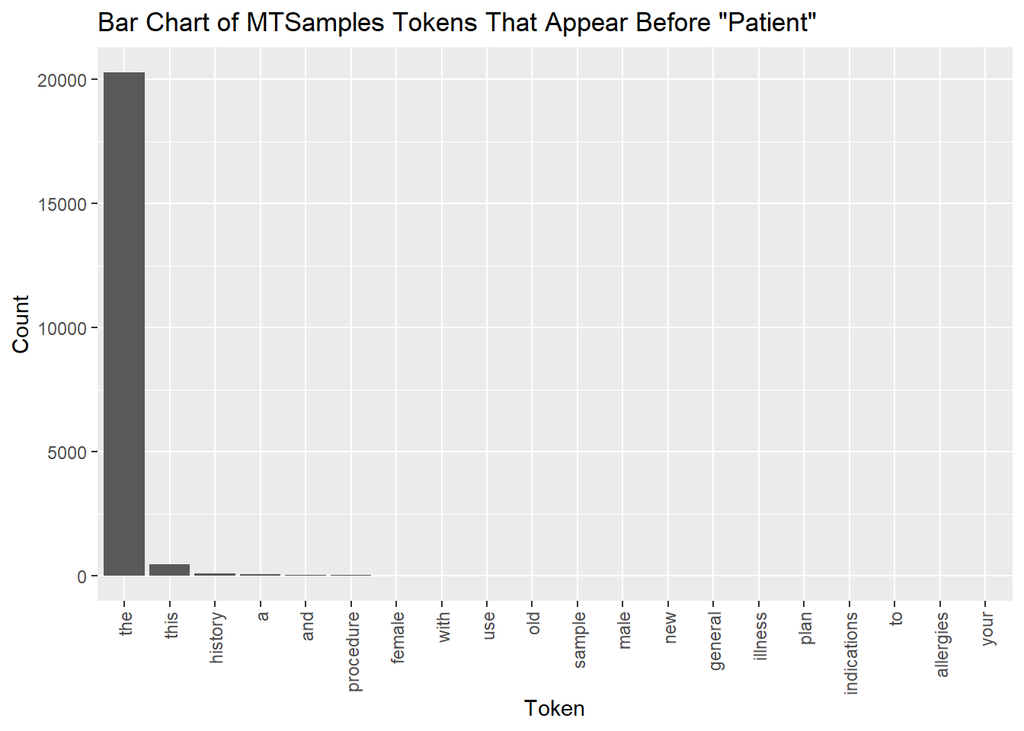

```r
ggplot(data = head(patient_token_counts, n = 20), aes(x = fct_reorder(word1, -n), y = n)) +
  geom_bar(stat = "identity") +
  labs(title = "Bar Chart of MTSamples Tokens That Appear Before \"Patient\"",
       y = "Count",
       x = "Token") +
  theme(axis.text.x = element_text(angle = 90, hjust = 1, vjust = 0.5))
```

```r
patient_token_counts <- patient_tokens %>%
  count(word3, sort = TRUE)
head(patient_token_counts)
```

```
      word3    n
1       was 6291
2        is 3332
3       has 1417
4 tolerated  994
5       had  886
6      will  616
```

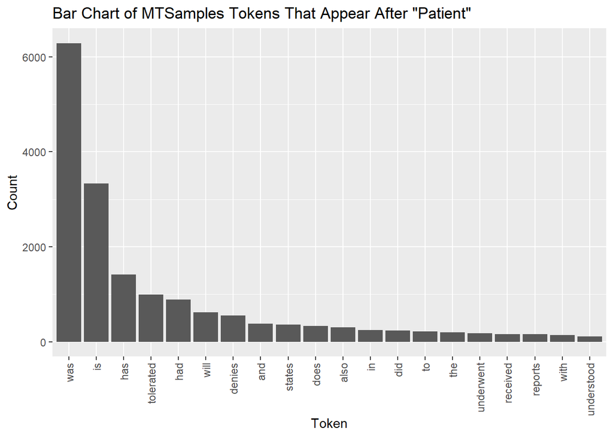

```r
ggplot(data = head(patient_token_counts, n = 20), aes(x = fct_reorder(word3, -n), y = n)) +
  geom_bar(stat = "identity") +
  labs(title = "Bar Chart of MTSamples Tokens That Appear After \"Patient\"",
       y = "Count",
       x = "Token") +
  theme(axis.text.x = element_text(angle = 90, hjust = 1, vjust = 0.5))
```

We find that the distribution of words that appear after “patient” is much more evenly distributed; however, the most common word after “patient” is “was”, followed by “is”, “has”, and “tolerated”. It makes sense that these words are either stopwords or verbs in the past tense, since the typical format of a medical report is to describe what happened to a patient in past tense.

# 6. Find most frequent words in each speciality

```r
mtsamples_tokens <- mtsamples %>%
  unnest_tokens(token, transcription) %>%
  filter(!str_detect(token, "^\\d{1,3}(,\\d{3})*(\\.\\d+)?$")) %>%
  anti_join(stop_words, by = c("token" = "word"))
```

```r
mtsamples_token_counts <- mtsamples_tokens %>%
  count(medical_specialty, token, sort = TRUE) %>%
  group_by(medical_specialty) %>%
  slice_max(n, n = 5, with_ties = FALSE) %>%
  ungroup()

mtsamples_token_counts
```

```
# A tibble: 200 × 3
   medical_specialty       token         n
   <chr>                   <chr>     <int>
 1 " Allergy / Immunology" history      38
 2 " Allergy / Immunology" noted        23
 3 " Allergy / Immunology" patient      22
 4 " Allergy / Immunology" allergies    21
 5 " Allergy / Immunology" nasal        13
 6 " Autopsy"              left         83
 7 " Autopsy"              inch         59
 8 " Autopsy"              neck         55
 9 " Autopsy"              anterior     47
10 " Autopsy"              body         40
# ℹ 190 more rows
```

# 7. Identify interesting 5-grams

```r
mtsamples_tokens <- mtsamples %>%
  unnest_ngrams(token, transcription, n = 5)
head(mtsamples_tokens)
```

```
  X                                                       description
1 0  A 23-year-old white female presents with complaint of allergies.
2 0  A 23-year-old white female presents with complaint of allergies.
3 0  A 23-year-old white female presents with complaint of allergies.
4 0  A 23-year-old white female presents with complaint of allergies.
5 0  A 23-year-old white female presents with complaint of allergies.
6 0  A 23-year-old white female presents with complaint of allergies.
      medical_specialty         sample_name
1  Allergy / Immunology  Allergic Rhinitis
2  Allergy / Immunology  Allergic Rhinitis
3  Allergy / Immunology  Allergic Rhinitis
4  Allergy / Immunology  Allergic Rhinitis
5  Allergy / Immunology  Allergic Rhinitis
6  Allergy / Immunology  Allergic Rhinitis
                                                                                                                             keywords
1 allergy / immunology, allergic rhinitis, allergies, asthma, nasal sprays, rhinitis, nasal, erythematous, allegra, sprays, allergic,
2 allergy / immunology, allergic rhinitis, allergies, asthma, nasal sprays, rhinitis, nasal, erythematous, allegra, sprays, allergic,
3 allergy / immunology, allergic rhinitis, allergies, asthma, nasal sprays, rhinitis, nasal, erythematous, allegra, sprays, allergic,
4 allergy / immunology, allergic rhinitis, allergies, asthma, nasal sprays, rhinitis, nasal, erythematous, allegra, sprays, allergic,
5 allergy / immunology, allergic rhinitis, allergies, asthma, nasal sprays, rhinitis, nasal, erythematous, allegra, sprays, allergic,
6 allergy / immunology, allergic rhinitis, allergies, asthma, nasal sprays, rhinitis, nasal, erythematous, allegra, sprays, allergic,
                                 token
1          subjective this 23 year old
2               this 23 year old white
3             23 year old white female
4       year old white female presents
5       old white female presents with
6 white female presents with complaint
```

```r
head(mtsamples_tokens$token)
```

```
[1] "subjective this 23 year old"
[2] "this 23 year old white"
[3] "23 year old white female"
[4] "year old white female presents"
[5] "old white female presents with"
[6] "white female presents with complaint"
```

```r
mtsamples_token_counts <- mtsamples_tokens %>%
  count(token) %>%
  arrange(desc(n))
```

```r
head(mtsamples_token_counts)
```

```
                                 token   n
1  the patient tolerated the procedure 855
2            prepped and draped in the 854
3 patient tolerated the procedure well 773
4            was prepped and draped in 706
5              and draped in the usual 690
6             the patient was taken to 678
```

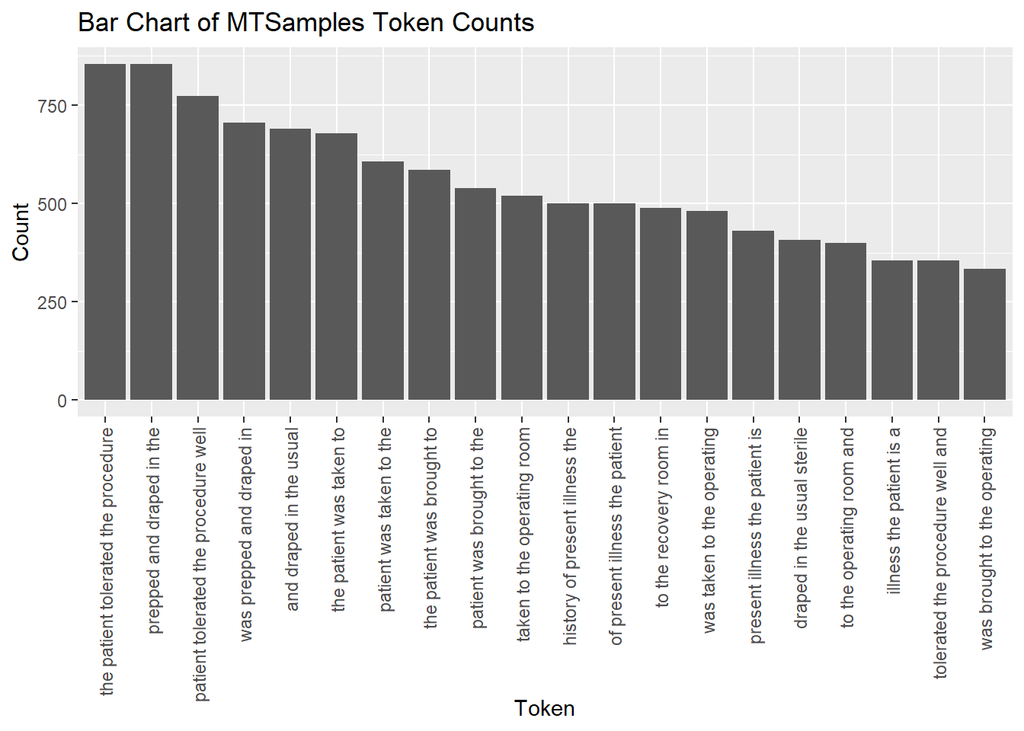

```r
ggplot(data = head(mtsamples_token_counts, n = 20), aes(x = fct_reorder(token, -n), y = n)) +
  geom_bar(stat = "identity") +
  labs(title = "Bar Chart of MTSamples Token Counts",
       y = "Count",
       x = "Token") +
  theme(axis.text.x = element_text(angle = 90, hjust = 1, vjust = 0.5))
```

Interestingly, nearly all of the most common 5-grams (groups of 5 words) in the transcription data describe either the patient tolerating a procedure or the patient being draped in sterile robes and taken to the operating room, which again highlights the necessity of consistent language between medical reports.